# Data Science With an Eye Towards Sustainability Activity A6: Data Wrangling

Ian Lum

# 1 US Births

The number of daily births in the US varies over the year and from day to day. What’s surprising to many people is that the variation from one day to the next can be huge: some days have only about 80% as many births as others. Why? In this activity we’ll use basic data wrangling skills to understand some drivers of daily births.

The data table `Birthdays_69_88`, which we read in from the `mosaicData` package gives the number of births recorded on each day of the year in each state from 1969 to 1988:

Table 1.1: A subset of the 1969-1988 birthday data.

| state | date | year | births |
| --- | --- | --- | --- |
| AK | 1969-01-01 | 1969 | 14 |
| AL | 1969-01-01 | 1969 | 174 |
| AR | 1969-01-01 | 1969 | 78 |
| AZ | 1969-01-01 | 1969 | 84 |
| CA | 1969-01-01 | 1969 | 824 |
| CO | 1969-01-01 | 1969 | 100 |
| CT | 1969-01-01 | 1969 | 90 |
| DC | 1969-01-01 | 1969 | 88 |

Meanwhile, the `fivethirtyeight` package has more recent data from 2000-2014, which we’ve stored in the data table `Birthdays_00_14`; however, this data does not include a breakdown by state:

Table 1.2: A subset of the 2000-2014 birthday data.

| date | births |
| --- | --- |
| 2000-01-01 | 9083 |
| 2000-01-02 | 8006 |
| 2000-01-03 | 11363 |
| 2000-01-04 | 13032 |
| 2000-01-05 | 12558 |
| 2000-01-06 | 12466 |
| 2000-01-07 | 12516 |
| 2000-01-08 | 8934 |

# 2 Data Wrangling Introduction

## 2.1 Tidy Data

Additional reading:

- [Wickham, Tidy Data](https://www.jstatsoft.org/article/view/v059i10)
- [Wickham and Grolemund, Tidy Data](http://r4ds.had.co.nz/tidy-data.html)
- [Baumer, Kaplan, and Horton, Tidy Data](https://mdsr-book.github.io/mdsr2e/ch-dataII.html#tidy-data)

There are different ways to store and represent the same data. In order to be consistent and to also take advantage of the vectorized nature of `R`, the `tidyverse` packages we’ll use provide a set of three interrelated rules/conventions for a dataset to be `tidy`:

1. Each variable must have its own column.
2. Each observation must have its own row.
3. Each value must have its own cell.

One of the first things we’ll often do when acquiring new data is to “tidy it” into this form. For now, we can already start thinking of a data frame (tibble) as a table whose rows are the individual cases and whose columns are the variables on which we have information for each individual case. The first figure from the [`tidyr` cheat sheet](https://rstudio.github.io/cheatsheets/tidyr.pdf) summarizes this principle.

## 2.2 Data Verbs

Additional reading:

- [Wickham and Grolemund, Data Transformation](https://r4ds.had.co.nz/transform.html)
- [Baumer, Kaplan, and Horton, A Grammar for Data Wrangling](https://mdsr-book.github.io/mdsr2e/ch-dataI.html)

There are six main data transformation verbs in the `dplyr` library. Each verb takes an input data frame along with additional arguments specifying the action, and returns a new data frame. We’ll examine them in three pairs.

**Verbs that change the variables (columns) but not the cases (rows)**

The first two verbs change which variables (columns) are included in the data frame, but preserve the same set of cases (rows).

- **`select()`** chooses which columns to keep, or put another way, deletes those colummns that are not selected. To specify the columns, we can either list them out, or use functions like `starts_with()`, `ends_with()`, or `contains()` to specify the titles of the variables we wish to keep.
- **`mutate()`** adds one or more columns to the data frame. Each column is a function of the other columns that is applied on a row by row basis. For example, we can use arithmetic operations like adding two other variables or logical operations like checking if two columns are equal, or equal to a target number.

**Example 2.1 (select and mutate)**

1. Add two new variables to the `Birthdays_69_88` data: one that has only the last two digits of the year, and one that states whether there were more than 100 births in the given state on the given date.
2. Then form a new table that only has four columns: the state, the date, and your two new columns.
3. What does the following operation return: `select(Birthdays_69_88,ends_with("te"))`?

*Solution*. The commands for the first two parts are

```r
Birthdays_69_88_extra <- mutate(Birthdays_69_88,
                         year_short=year-1900,
                         busy_birthday=(births>100))
Birthdays_69_88_extra_table <- select(Birthdays_69_88_extra,state,date, year_short,busy_birthday)
```

The operation in (c) selects only the first two columns `state` and `date`.

**Verbs that change the cases (rows) but not the variables (columns)**

The next two verbs change which cases (rows) are included in the data frame, but preserve the same set of variables (columns).

- **`filter()`** deletes some of the rows by specifying which rows to keep.
- **`arrange()`** reorders the rows according to a specified criteria. To sort in reverse order based on the variable `x`, use `arrange(desc(x))`.

**Example 2.2 (filter and arrange)** Create a table with only births in Massachusetts in 1979, and sort the days from those with the most births to those with the fewest.

*Solution*. We want to `filter` and then `arrange`:

```r
MABirths1979 <- filter(Birthdays_69_88, state=="MA", year==1979)
MABirths1979Sorted <- arrange(MABirths1979, desc(births))
```

Table 2.1: Birthdays in Massachusetts in 1979, sorted from those dates with the most births to those dates with the fewest births.

| state | date | year | births |
| --- | --- | --- | --- |
| MA | 1979-09-28 | 1979 | 262 |
| MA | 1979-09-11 | 1979 | 252 |
| MA | 1979-12-28 | 1979 | 249 |
| MA | 1979-09-26 | 1979 | 246 |
| MA | 1979-07-24 | 1979 | 245 |
| MA | 1979-04-27 | 1979 | 243 |

When filtering, we often use logical comparison operators like `==`, `>`, `<`, `>=` (greater than or equal to), `<=` (less than or equal to), and `%in%`, which compares the value to a list of entries.[^1] For example, if we want all births in AK, CA, and MA, we can write

```
filter(Birthdays_69_88, state %in% c("AK","CA","MA"))
```

The `c()` here is for concatenate, which is how we form vectors in `R`.

**Grouped summaries**

- **`summarise()`** (or equivalently **`summarize()`**) takes an entire data frame as input and outputs a single row with one or more summary statistics, such as `mean`, `sum`, `sd`, `n_distinct()`, or `n()` (which, like `tally()`, just counts the number of entries).

```r
summarise(Birthdays_69_88,total_births=sum(births),
          average_births=mean(births),
          nstates=n_distinct(state),ncases=n())
```

```
##   total_births average_births nstates ncases
## 1     70486538       189.0409      51 372864
```

So `summarise` changes both the cases and the variables. Alone, `summarise` is not all that useful, because we can also access individual variables directly with the dollar sign. For example, to find the total and average births, we can write

```r
sum(Birthdays_69_88$births)
```

```
## [1] 70486538
```

```r
mean(Birthdays_69_88$births)
```

```
## [1] 189.0409
```

Rather, we will mostly use it to create **grouped summaries**, which brings us to the last of the six main data verbs.

- **`group_by()`** groups the cases of a data frame by a specified set of variables. The size of the stored data frame does not actually change (neither the cases nor the variables change), but then other functions can be applied to the specified groups instead of the entire data set. We’ll often use `group_by` in conjunction with `summarise` to get a grouped summary.

**Example 2.3 (Grouped summary)**

1. Find the number of births totaled over the entire 1969-1988 time range, for each state (51 numbers).
2. Find the average number of daily births in each year (1969-1988), by state.

*Solution*. We have to first group by the desired grouping and then perform a summarise.

```r
Birthdays_69_88_by_state<-group_by(Birthdays_69_88,state)
summarise(Birthdays_69_88_by_state, total=sum(births))
```

```
## # A tibble: 51 × 2
##    state   total
##    <chr>   <int>
##  1 AK     185385
##  2 AL    1206772
##  3 AR     684220
##  4 AZ     947234
##  5 CA    7822785
##  6 CO     946378
##  7 CT     824338
##  8 DC     425469
##  9 DE     188705
## 10 FL    2624301
## # ℹ 41 more rows
```

```r
Birthdays_69_88_by_year_state<-group_by(Birthdays_69_88,year,state)
summarise(Birthdays_69_88_by_year_state, average=mean(births))
```

```
## # A tibble: 1,020 × 3
## # Groups:   year [20]
##     year state average
##    <int> <chr>   <dbl>
##  1  1969 AK       18.6
##  2  1969 AL      174.
##  3  1969 AR       91.3
##  4  1969 AZ       93.3
##  5  1969 CA      954.
##  6  1969 CO      110.
##  7  1969 CT      134.
##  8  1969 DC       75.3
##  9  1969 DE       27.6
## 10  1969 FL      292.
## # ℹ 1,010 more rows
```

## 2.3 Piping

Additional reading:

- [Wickham and Grolemund, Combining Multiple Operations with the Pipe](https://r4ds.had.co.nz/transform.html#combining-multiple-operations-with-the-pipe)
- [Wickham and Grolemund, Pipes](http://r4ds.had.co.nz/pipes.html)

Pipes offer an efficient way to execute multiple operations at once. Here is a more efficient way to redo Example 2.2 with **the pipe**:

```r
QuickMABirths1979<-
  Birthdays_69_88 %>%
  filter(state=="MA",year==1979) %>%
  arrange(desc(births))
```

With the pipe notation, `x%>%f(y)` becomes `f(x,y)`, where in the first line here, `x` is `Birthdays`, the function `f` is `filter`, and `y` is `state=="MA",year==1979`. The really nice thing about piping is that you can chain together a bunch of different operations without having to save the intermediate results. This is what we have done above by chaining together a `filter` followed by an `arrange`.

**Note**: The pipe `%>%` is in the `magrittr` package, which is loaded with `tidyverse`. Version 4.1.0 of `R` introduced a new pipe in base `R` (no package loading required); it is `|>`. For everything we do in this course, they will work exactly the same. Some more advanced functionality is included in `%>%` than `|>`, as described in [this article](https://www.tidyverse.org/blog/2023/04/base-vs-magrittr-pipe/). If you prefer to use the `|>` pipe throughout, that is totally fine (and it is one character shorter). The updated version of the piping readings with the `|>` pipe are here:

- [Wickham, Çetinkaya-Rundel, and Grolemund, dplyr basics](https://r4ds.hadley.nz/data-transform.html#the-pipe)
- [Wickham, Çetinkaya-Rundel, and Grolemund, The pipe](https://r4ds.hadley.nz/data-transform.html#sec-the-pipe)

## 2.4 Manipulating Dates

Additional reading:

- [Wickham and Grolemund, Date and Times with `lubridate`](http://r4ds.had.co.nz/dates-and-times.html)
- [`lubridate` cheat sheet](https://rstudio.github.io/cheatsheets/lubridate.pdf)

The `date` variable in `Birthdays_69_88` prints out in the conventional, human-readable way. But it is actually in a format (called `POSIX` date format) that automatically respects the order of time. The `lubridate` package contains helpful functions that will extract various information about any date. Here are some you might find useful:

- `year()`
- `month()`
- `week()`
- `yday()` — gives the day of the year as a number 1-366. This is often called the “Julian day.”
- `mday()` — gives the day of the month as a number 1-31
- `wday()` — gives the weekday (e.g. Monday, Tuesday, …). Use the optional argument `label=TRUE` to have the weekday spelled out rather than given as a number 1-7.

Using these `lubridate` functions, you can easily look at the data in more detail. For example, we can add columns to the date table for month and day of the week:[^2]

```r
Birthdays_69_88<-
  Birthdays_69_88 %>%
  mutate(month=month(date,label=TRUE),
         weekday=wday(date,label=TRUE))
```

Here is what the data table looks like with our new columns:

Table 2.2: A subset of the updated 1969-1988 birthday data.

| state | date | year | births | month | weekday |
| --- | --- | --- | --- | --- | --- |
| AK | 1969-01-01 | 1969 | 14 | Jan | Wed |
| AL | 1969-01-01 | 1969 | 174 | Jan | Wed |
| AR | 1969-01-01 | 1969 | 78 | Jan | Wed |
| AZ | 1969-01-01 | 1969 | 84 | Jan | Wed |
| CA | 1969-01-01 | 1969 | 824 | Jan | Wed |
| CO | 1969-01-01 | 1969 | 100 | Jan | Wed |
| CT | 1969-01-01 | 1969 | 90 | Jan | Wed |
| DC | 1969-01-01 | 1969 | 88 | Jan | Wed |

**Example 2.4** Make a table showing the five states with the most births between September 9, 1979 and September 11, 1979, inclusive. Arrange the table in descending order of births.

*Solution*. The plan of attack is to first filter the dates, then group by state, then use a `summarise` to add up totals for each state, and finally arrange them in descending order to find the top 5.[^3]

```r
SepTable<-
  Birthdays_69_88 %>%
  filter(date >= ymd(19790909), date <=ymd(19790911)) %>%
  group_by(state) %>%
  summarise(total=sum(births)) %>%
  arrange(desc(total)) %>%
  head(n=5)
```

```r
knitr::kable(
  SepTable[,], caption = 'States with the
  most births between September 9, 1979
  and September 11, 1979, inclusive.'
)
```

Table 2.3: States with the most births between September 9, 1979 and September 11, 1979, inclusive.

| state | total |
| --- | --- |
| CA | 3246 |
| TX | 2347 |
| NY | 1943 |
| IL | 1673 |
| OH | 1408 |

# 3 Practice

**Exercise 3.1 (Visualize data)** Using the `Birthdays_00_14` data, make a scatterplot of the daily births (y-axis) vs. date (x-axis).

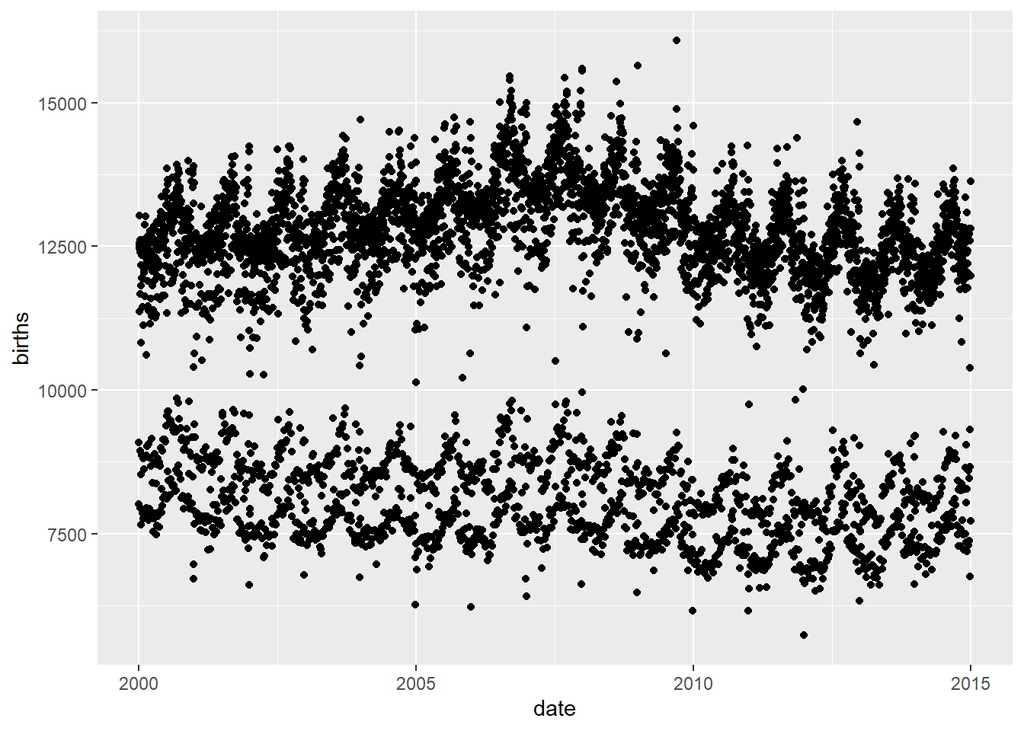

```r
ggplot(Birthdays_00_14 ,aes(x=date, y=births)) + geom_point()
```

**Exercise 3.2 (Wrangling practice)** Use wrangling commands to efficiently find the following:

1. The day in September with the most total births between 2000 and 2014.
2. The day in July with the fewest total births between 2000 and 2014.
3. The number of total births in 2000-2004, 2005-2009, and 2010-2014.

```r
Birthdays_00_14 %>%
  filter(month(date)==9) %>%
  arrange(desc(births))
```

```
## # A tibble: 450 × 2
##    date       births
##    <date>      <int>
##  1 2009-09-09  16081
##  2 2006-09-07  15454
##  3 2007-09-05  15440
##  4 2006-09-06  15391
##  5 2006-09-19  15205
##  6 2007-09-18  15194
##  7 2007-09-20  15139
##  8 2006-09-14  15099
##  9 2006-09-12  15078
## 10 2006-09-08  15018
## # ℹ 440 more rows
```

```r
Birthdays_00_14 %>%
  filter(month(date)==7) %>%
  arrange(births)
```

```
## # A tibble: 465 × 2
##    date       births
##    <date>      <int>
##  1 2010-07-04   7279
##  2 2009-07-05   7333
##  3 2011-07-24   7351
##  4 2010-07-18   7352
##  5 2010-07-11   7382
##  6 2010-07-25   7392
##  7 2011-07-31   7450
##  8 2013-07-07   7454
##  9 2011-07-03   7489
## 10 2013-07-28   7492
## # ℹ 455 more rows
```

```r
Birthdays_00_14 %>%
  mutate(year=year(date)) %>%
  mutate(year_group = case_when(year %in% 2000:2004 ~ "2000-2004",
                            year %in% 2004:2009 ~ "2004-2009",
                            year %in% 2009:2014 ~ "2009-2014",
                            )) %>%
  group_by(year_group) %>%
  summarise(total=sum(births))
```

```
## # A tibble: 3 × 2
##   year_group    total
##   <chr>         <int>
## 1 2000-2004  20709797
## 2 2004-2009  21429607
## 3 2009-2014  20047620
```

We are now ready to investigate some drivers of daily births in the US.

## 3.1 Seasonality

**Exercise 3.3 (Examine seasonality)** To examine seasonality in birth rates, look at the number of births from 2000-2014 by

1. week of the year (1-53)
2. month of the year (January to December)
3. Julian day (1-366)

For each of these categories (week, month, Julian day), (i) make a scatter plot with births on the y-axis and the corresponding category on the x-axis; (ii) use wrangling commands to list the three weeks/months/Julian days with the most total births across the 2000-2014 range (in descending order); (iii) use wrangling commands to list the three weeks/months/Julian days with the fewest total births across the 2000-2014 range (in ascending order).

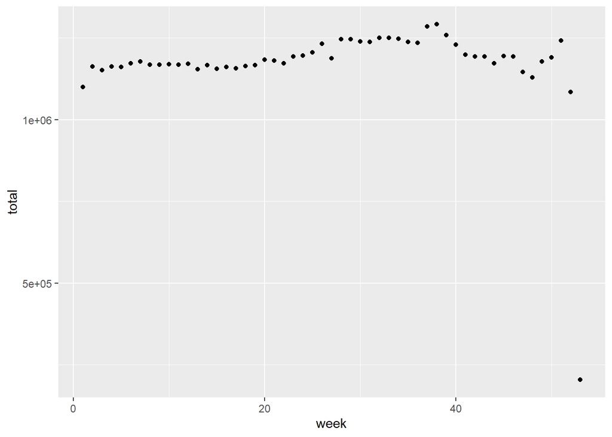

```r
ByWeek_00_14 <- Birthdays_00_14 %>%
  mutate(week=week(date)) %>%
  group_by(week) %>%
  summarize(total=sum(births))

ggplot(ByWeek_00_14, aes(x=week, y=total))+
  geom_point()
```

```r
ByWeek_00_14 %>%
  arrange(desc(total))
```

```
## # A tibble: 53 × 2
##     week   total
##    <dbl>   <int>
##  1    38 1291837
##  2    37 1284596
##  3    39 1258476
##  4    33 1250184
##  5    32 1250018
##  6    34 1248137
##  7    28 1246184
##  8    29 1245711
##  9    51 1241624
## 10    30 1239563
## # ℹ 43 more rows
```

```r
ByWeek_00_14 %>%
  arrange(total)
```

```
## # A tibble: 53 × 2
##     week   total
##    <dbl>   <int>
##  1    53  204139
##  2    52 1084551
##  3     1 1100362
##  4    48 1129774
##  5    47 1145812
##  6     3 1151073
##  7    13 1153698
##  8    15 1155893
##  9    17 1156753
## 10     5 1161140
## # ℹ 43 more rows
```

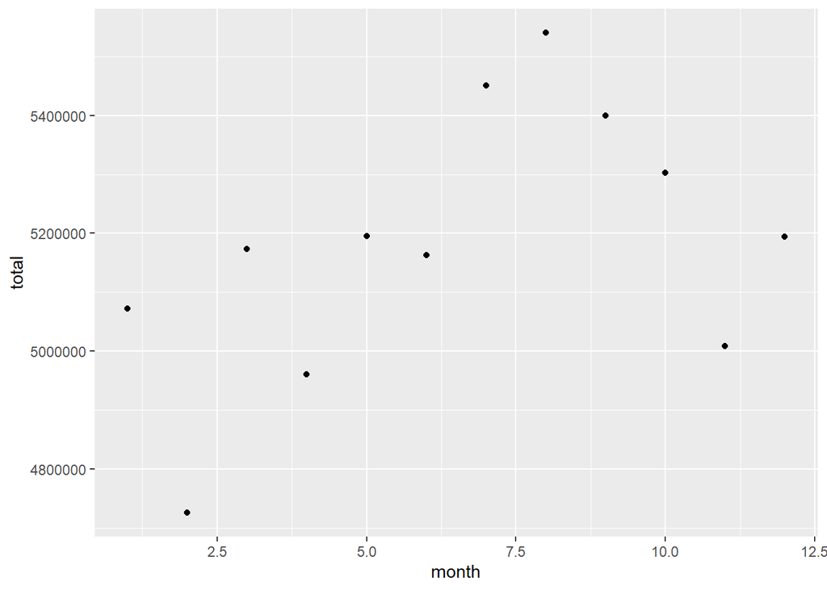

```r
ByMonth_00_14 <- Birthdays_00_14 %>%
  mutate(month=month(date)) %>%
  group_by(month) %>%
  summarize(total=sum(births))

ggplot(ByMonth_00_14, aes(x=month, y=total))+
  geom_point()
```

```r
ByMonth_00_14 %>%
  arrange(desc(total))
```

```
## # A tibble: 12 × 2
##    month   total
##    <dbl>   <int>
##  1     8 5540170
##  2     7 5450418
##  3     9 5399592
##  4    10 5302865
##  5     5 5195445
##  6    12 5194432
##  7     3 5172961
##  8     6 5163360
##  9     1 5072588
## 10    11 5008750
## 11     4 4960750
## 12     2 4725693
```

```r
ByMonth_00_14 %>%
  arrange(total)
```

```
## # A tibble: 12 × 2
##    month   total
##    <dbl>   <int>
##  1     2 4725693
##  2     4 4960750
##  3    11 5008750
##  4     1 5072588
##  5     6 5163360
##  6     3 5172961
##  7    12 5194432
##  8     5 5195445
##  9    10 5302865
## 10     9 5399592
## 11     7 5450418
## 12     8 5540170
```

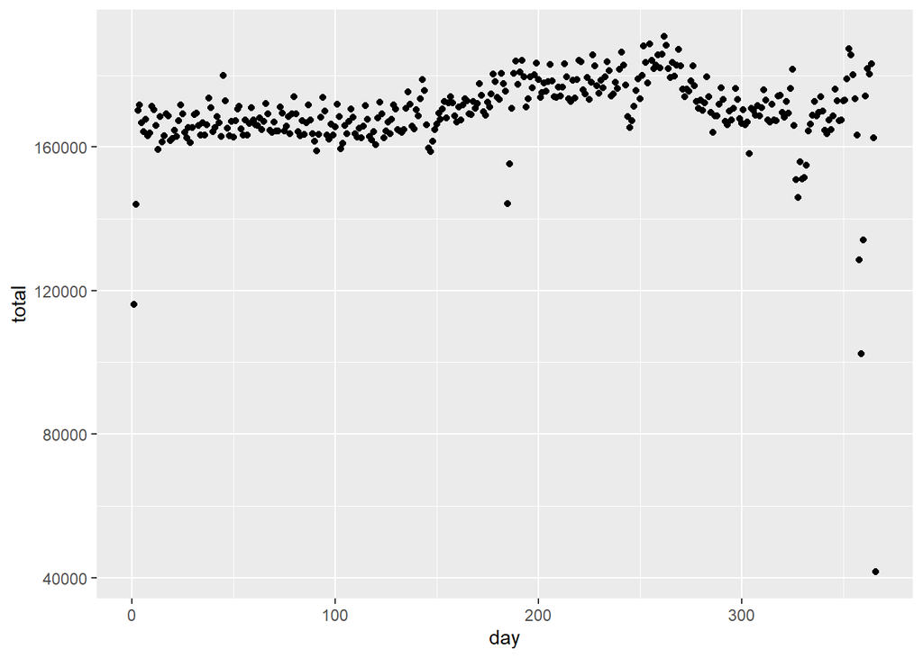

```r
ByDay_00_14 <- Birthdays_00_14 %>%
  mutate(day=yday(date)) %>%
  group_by(day) %>%
  summarize(total=sum(births))

ggplot(ByDay_00_14, aes(x=day, y=total))+
  geom_point()
```

```r
ByDay_00_14 %>%
  arrange(desc(total))
```

```
## # A tibble: 366 × 2
##      day  total
##    <dbl>  <int>
##  1   262 190774
##  2   255 188721
##  3   263 188376
##  4   252 188182
##  5   353 187290
##  6   269 187117
##  7   241 186340
##  8   261 185842
##  9   354 185707
## 10   227 185698
## # ℹ 356 more rows
```

```r
ByDay_00_14 %>%
  arrange(total)
```

```
## # A tibble: 366 × 2
##      day  total
##    <dbl>  <int>
##  1   366  41562
##  2   359 102427
##  3     1 116030
##  4   358 128629
##  5   360 134153
##  6     2 144083
##  7   185 144293
##  8   328 145844
##  9   327 150876
## 10   330 151097
## # ℹ 356 more rows
```

## 3.2 Day of the Week

**Exercise 3.4 (Examine patterns within the week)** To examine patterns within the week, make a box plot showing the number of births by day of the week. Interpret your results. What might be causing this pattern?

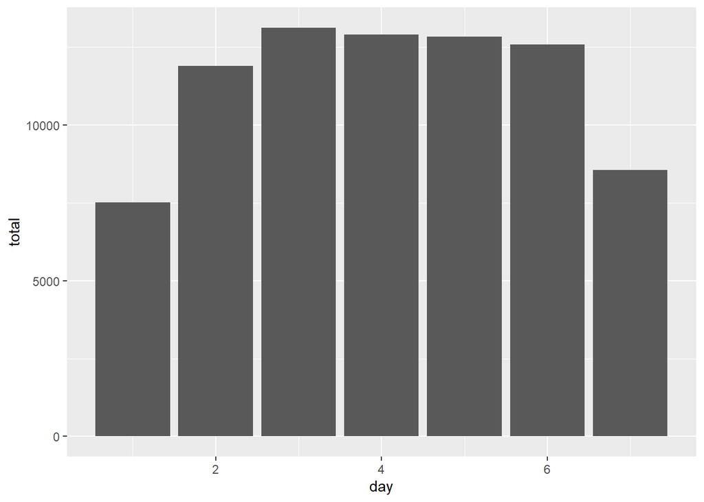

```r
ggplot(
  Birthdays_00_14 %>%
    mutate(day=wday(date)) %>%
    group_by(day) %>%
    summarize(total=mean(births)),
  aes(x=day, y=total)
)+
  geom_col()
```

## 3.3 Holidays

**Exercise 3.5 (Two year sample)** Pick a two-year span of the `Birthdays` that falls in the 2000s, say, 2003/2004. Extract out the data just in this interval, calling it `MyTwoYears`. (Hint: `filter()`, `year()`). Plot out the births in this two-year span day by day. Color each date according to its day of the week. Make sure to choose your font size, line widths, and color scheme to make your figure legible. Explain the pattern that you see.

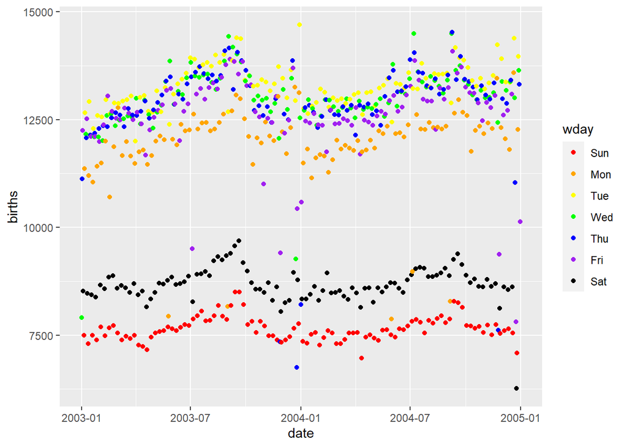

```r
MyTwoYears <- Birthdays_00_14 %>%
  mutate(year=year(date)) %>%
  filter(year %in% c(2003,2004)) %>%
  mutate(wday=wday(date, label = T))

ggplot(MyTwoYears, aes(x=date, y=births, color=wday)) +
  scale_color_manual(values=c("red","orange","yellow","green","blue","purple","black"))+
  geom_point()
```

*Solution*. Less births on weekends, likely becuase many births are scheduled, and people tend to schedule births on weekdays.

The plot you generate for Exercise 3.5 should be generally consistent with the weekend effect and seasonal patterns we have already seen; however, a few days each year stand out as exceptions. We are going to examine the hypothesis that these are holidays. You can find a data set listing US federal holidays at `http://faculty.olin.edu/dshuman/data/112/US-Holidays.csv`. Read it in as follows:[^4]

```r
Holidays <- read_csv("http://faculty.olin.edu/dshuman/data/112/US-Holidays.csv") %>%
  mutate(date = as.Date(lubridate::dmy(date)))
```

**Exercise 3.6 (Holidays)** Now let’s update the plot from Exercise 3.5 to include the holidays.

1. Add a variable to `MyTwoYears` called `is_holiday`. It should be `TRUE` when the day is a holiday, and `FALSE` otherwise. One way to do this is with the transformation verb `%in%`, for instance, `is_holiday = date %in% Holidays$date`.
2. Add a `geom_point` layer to your plot that sets the color of the points based on the day of the week and the shape of the points based on whether or not the day is a holiday.
3. Finally, some holidays seem to have more of an effect than others. It would be helpful to label them. Use `geom_text` with the holiday data to add labels to each of the holidays. Hints: 1. Start by making a new data table called `MyHolidays` that just contains the holidays in your selected two year window. 2. Start your geometry line with `geom_text(data=MyHolidays)`. 3. You’ll have to make up a y-coordinate for each label. 4. You can set the orientation of each label with the `angle` argument; e.g., `geom_text(data=MyHolidays, angle=40, ...)`.

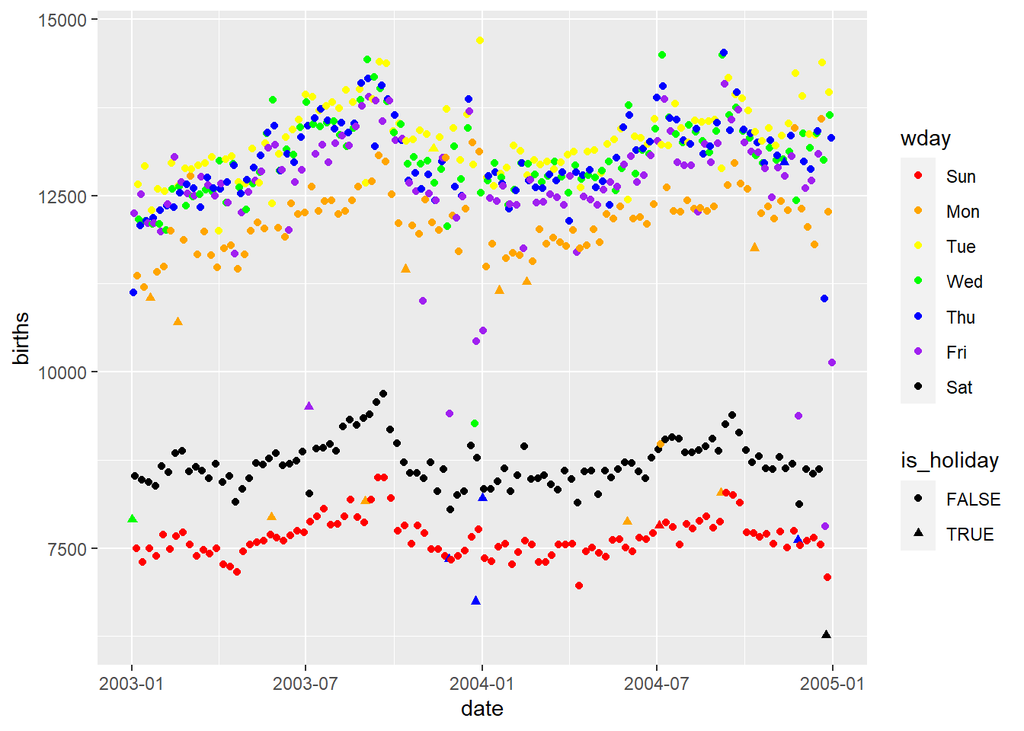

```r
TwoYears_holidays <- MyTwoYears %>%
  mutate(is_holiday = date %in% Holidays$date)
  # mutate(holiday_date = ifelse(is_holiday,
                               # date,
                               # Holidays[Holidays$date == date,]$holiday,
                               # ""))

ggplot(TwoYears_holidays, aes(x=date, y=births, color=wday, shape=is_holiday)) +
  scale_color_manual(values=c("red","orange","yellow","green","blue","purple","black"))+
  geom_point()
```

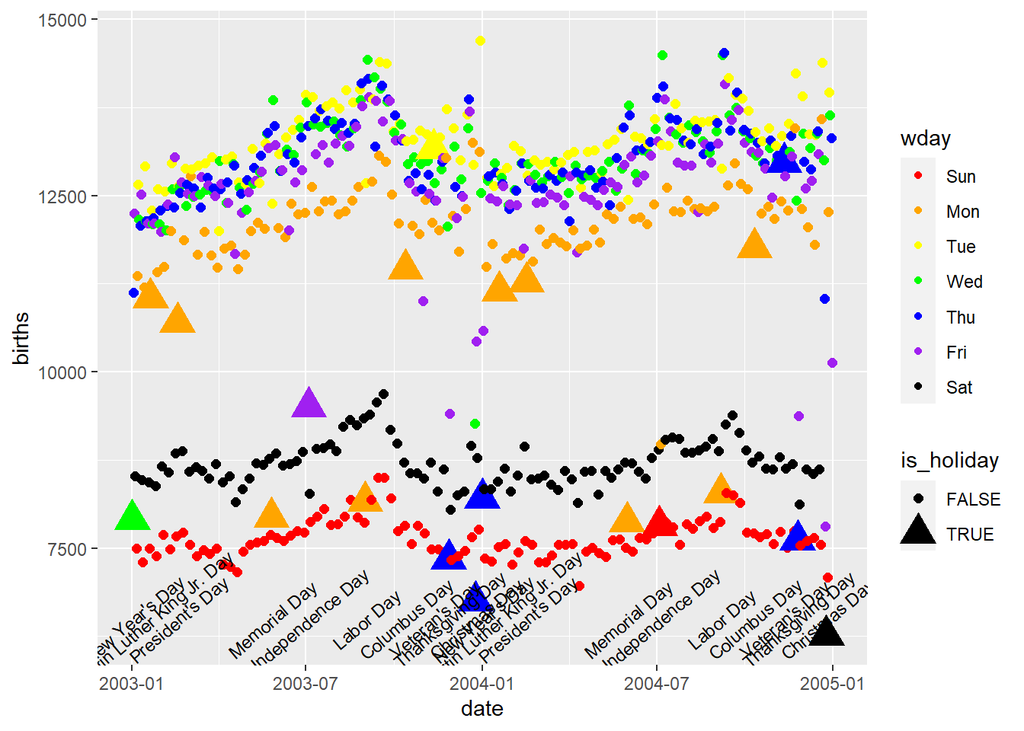

```r
MyHolidays <- Holidays %>% filter(year %in% c(2003, 2004))

ggplot() +
  geom_point(data=TwoYears_holidays, aes(x=date, y=births, color=wday, shape=is_holiday, size=is_holiday))+
  scale_color_manual(values=c("red","orange","yellow","green","blue","purple","black"))+
  geom_text(data=MyHolidays, aes(x=date, label=holiday), y=6500, angle=40, size=3)
```

## 3.4 Geography

**Exercise 3.7 (Examine the effect of geography)** In any way you choose, explore the effect of geography on birth patterns, using the `Birthdays_69_88` data. For example, do parents in Minnesota have fewer winter babies than in other states? Which states have the largest increases or decreases in their portion of US births over time? Is the weekend effect less strong for states with a higher percentage of their populations living in rural areas? Pick any issue (not all of these) that interests you, explore it, and create a graphic to illustrate your findings.

*Solution*. Research question: which state cares the most about Christmas? (my dad was born on Christmas)

```r
ChristmasBirths <- Birthdays_69_88 %>%
  filter(month(date)==12 & day(date)==25) %>%
  group_by(state) %>%
  summarize(xmas_average=mean(births))

NonChristmasBirths <- Birthdays_69_88 %>%
  filter(!(month(date)==12 & day(date)==25)) %>%
  group_by(state) %>%
  summarize(non_xmas_average=mean(births))

ChristmasBirths$non_xmas_average <- NonChristmasBirths$non_xmas_average
ChristmasBirths <- ChristmasBirths %>%
  mutate(percent_diff = (non_xmas_average - xmas_average)/non_xmas_average) %>%
  arrange(desc(percent_diff))
ChristmasBirths
```

```
## # A tibble: 51 × 4
##    state xmas_average non_xmas_average percent_diff
##    <chr>        <dbl>            <dbl>        <dbl>
##  1 UT            64.4             97.8        0.342
##  2 ME            30.4             43.8        0.308
##  3 ND            23.2             32.7        0.291
##  4 NH            26.3             36.3        0.275
##  5 WY            15.6             21.1        0.263
##  6 MT            25.6             34.8        0.263
##  7 MN           129.             174.         0.258
##  8 CT            84.0            113.         0.256
##  9 VT            15.1             20.3        0.255
## 10 OH           345.             456.         0.244
## # ℹ 41 more rows
```

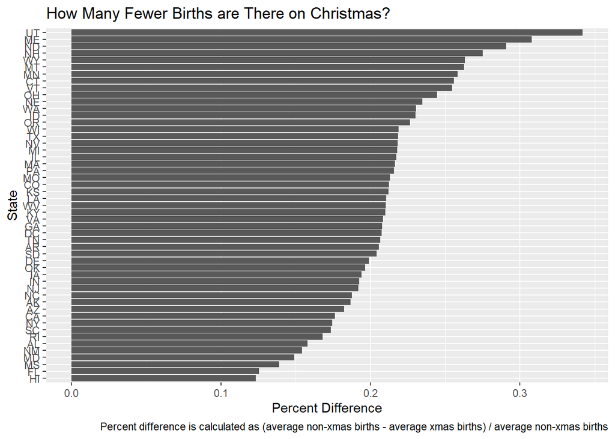

```r
ggplot(ChristmasBirths, aes(x=reorder(state, percent_diff), y=percent_diff))+
  geom_col()+
  coord_flip()+
  labs(title="How Many Fewer Births are There on Christmas?",
       y="Percent Difference",
       x="State",
       caption="Percent difference is calculated as (average non-xmas births - average xmas births) / average non-xmas births")
```

## 3.5 Superstition

This [article](https://fivethirtyeight.com/features/some-people-are-too-superstitious-to-have-a-baby-on-friday-the-13th/) from FiveThirtyEight demonstrates that fewer babies are born on the 13th of each month, and the effect is even stronger when the 13th falls on a Friday.

**Exercise 3.8 (Optional challenge)** If you have extra time or want some extra practice, you can try to recreate the first graphic in the [article](https://fivethirtyeight.com/features/some-people-are-too-superstitious-to-have-a-baby-on-friday-the-13th/) (for the 2000-2014 data we have).

[^1]: **Important note about `=` vs. `==`**: A single `=` is an assignment operator that assigns the value after the equal sign to the variable before the equal sign. We saw an example of this above with `year_short=year-1900`. In order to compare whether two values are the same, we need to use the double equal `==` as in `year==1979`.
[^2]: The `label=TRUE` argument tells `month` to return a string abbreviation for the month instead of the month’s number.
[^3]: The verbs `head(n=5)`, `tail(n=3)` are often used just after an `arrange` to keep, e.g., only the first 5 entries or last 3 entries, where `n` specifies the number of entries to keep.
[^4]: The point of the `lubridate::dmy()` function is to convert the character-string date stored in the CSV to a POSIX date-number.